# Peekbank Item Prediction

Martin Z

28 January, 2021

```r
library(knitr)
library(peekbankr)
library(tidyverse)
library(lme4)
library(lmerTest)
library(tictoc)
library(langcog)
library(here)
#library(tidymodels)
library(wordbankr)
#devtools::install_github("tidymodels/multilevelmod")
#library(multilevelmod)

figure_path <- here("figures")

load(file = "data/aoi_data_joined.Rds")
knitr::opts_chunk$set(cache = TRUE, warning = FALSE, message = FALSE)
dataset_name_mapping <- read_csv(here("data","dataset_name_mapping.csv"))

con <- connect_to_peekbank()
stimuli <- get_stimuli(connection = con) %>% collect()
subjects <- get_subjects(connection = con) %>% collect()

aoi_data_joined <- aoi_data_joined %>%
  left_join(subjects)
```

The goal is to explore relationships between item-level properties (specifically, child-directed word frequency and age of acquisition) and accurate looking in the looking while listening paradigm across age.

## Preparing the data

### Fit and filter trial accuracy (proportion looking to target)

Compute trial-level accuracy (proportion looking to the target) in a fixed critical window (300-2000ms).

We are focusing only on

- familiar words
- ages between 12-60 months
- English datasets (since this is what we have norms for)

```r
t_min <- 300
t_max <- 2000

by_trial_means <- aoi_data_joined %>%
  #remove dataset
  #filter(dataset_name!="pomper_saffran_2016") %>%
  #restrict to english datasets
  filter(native_language == "eng") %>%
  #restrict age range
  filter(age > 12, age <= 60) %>%
  # familiar target items only %>%
  filter(stimulus_novelty == "familiar") %>%
  #window of analysis
  filter(t_norm > t_min, t_norm < t_max) %>%
  mutate(age_binned = cut(age, seq(12,60,12))) %>%
  rename(target_label = english_stimulus_label) %>%
  group_by(administration_id, trial_id, target_label, distractor_id,
           age, age_binned) %>%
  summarise(prop_looking = sum(aoi == "target", na.rm = TRUE) /
              (sum(aoi == "target", na.rm=TRUE) +
                 sum(aoi=="distractor", na.rm=TRUE)),
            prop_missing = mean(aoi == "missing", na.rm = TRUE)) %>%
  left_join(stimuli, by = c("distractor_id" = "stimulus_id")) %>%
  rename(distractor_label = english_stimulus_label)
```

Filter the data to trials where there is sufficient looking data (target or distractor looking on at least 2/3 of the trial)

```r
acc_mod_data <- by_trial_means %>%
  ungroup() %>%
  filter(prop_missing < 1/3) %>%
  mutate(age_centered = age - mean(age,na.rm=TRUE))

target_label_counts <- acc_mod_data %>%
  ungroup() %>%
  group_by(target_label) %>%
  summarize(
    trial_count=n()
  )

acc_mod_data <- acc_mod_data %>%
  left_join(target_label_counts)
```

### Add English Frequency Info

TO DO: re-extract frequency information using childes-db. Source for the current frequency values: https://github.com/mikabr/aoa-prediction

```r
freq <- read_csv(here("data/childes_english.csv"))

acc_mod_freq <- left_join(acc_mod_data,
                      select(freq,word, word_count),by = c("target_label" = "word")) %>%
  rename(target_word_count=word_count) %>%
  left_join(select(freq,word, word_count),by = c("distractor_label" = "word")) %>%
  rename(distractor_word_count=word_count) %>%
  ungroup() %>%
  mutate(target_log_freq = log(target_word_count),
         distractor_log_freq = log(distractor_word_count)) %>%
  mutate(target_log_freq_centered = target_log_freq-mean(target_log_freq,na.rm=TRUE),
         distractor_log_freq_centered = distractor_log_freq-mean(distractor_log_freq,na.rm=TRUE)) %>%
  mutate(luce_log_freq = target_log_freq/ (target_log_freq+distractor_log_freq))

by_target_item_means <- acc_mod_freq %>%
  ungroup() %>%
  group_by(target_label,target_word_count,target_log_freq,age_binned) %>%
  summarise(
    N=n(),
    mean_prop_looking=mean(prop_looking,na.rm=TRUE)
  )
```

### Collect English AOA Information

Run this code chunk to collect AOA information from the English (American) WS form on Wordbank. After identifying target labels that cannot be found on Wordbank, a .csv is exported to resolve inconsistencies by hand (e.g. “chicken” == “chicken (animal)” in Wordbank).

```r
items_for_aoa <- unique(acc_mod_data$target_label)
#get wordbank items
wordbank_items_eng_ws <- get_item_data(language = "English (American)", form = "WS")
#compare to target label names
setdiff(items_for_aoa,wordbank_items_eng_ws$definition)
#output set difference for manual processing
write_csv(data.frame(target_label=setdiff(items_for_aoa,wordbank_items_eng_ws$definition)),here("data","items_dropped_aoa.csv"))

#set up and read in mapping file w/ aligned definitions for worddbank
stimulus_label_wordbank_intersect <- data.frame(
  target_label=intersect(items_for_aoa,wordbank_items_eng_ws$definition),
  definition=intersect(items_for_aoa,wordbank_items_eng_ws$definition))
stimulus_label_wordbank_mapping <- read_csv(here("data","stimulus_label_wordbank_mapping.csv"))
stimulus_label_wordbank <- bind_rows(stimulus_label_wordbank_intersect,stimulus_label_wordbank_mapping)

item_names_for_wordbank <- stimulus_label_wordbank$definition[!is.na(stimulus_label_wordbank$definition)]

items_for_wordbank <- filter(wordbank_items_eng_ws,definition %in% c(item_names_for_wordbank))$item_id

#get instrument data for target label items from wordbank
eng_ws_data <- get_instrument_data(language = "English (American)",
                                   form = "WS",
                                   items = items_for_wordbank,
                                   administrations=TRUE,
                                   iteminfo=TRUE)

#fit AOA curves to obtain AOA estimates (logistic regression)
aoas_ws_produces <- fit_aoa(eng_ws_data,measure="produces", age_min=0) %>%
  ungroup() %>%
  select(aoa,item_id,definition) %>%
  left_join(stimulus_label_wordbank) %>%
  select(target_label,definition,aoa)

write_csv(aoas_ws_produces,here("data","aoas_wordbank_ws_produces.csv"))
```

### Add English AOAs

```r
#aoas <- read_csv(here("data","bglm_aoas_english.csv"))
aoas <- read_csv(here("data","aoas_wordbank_ws_produces.csv"))

acc_mod_freq_aoa <- left_join(acc_mod_freq,
                      aoas) %>% #%>%
                        # transmute(target_label = definition,
                        #           target_aoa = bglm_aoa,
                        #           target_category = category)) %>%
  rename(target_aoa=aoa) %>%
  left_join(aoas  %>%
              transmute(distractor_label = definition,
                       distractor_aoa = aoa)) %>%
  filter(!is.na(target_aoa), !is.na(distractor_aoa)) %>%
  ungroup() %>%
  mutate(target_aoa_centered = target_aoa - mean(target_aoa,na.rm=TRUE),
         distractor_aoa_centered = distractor_aoa - mean(distractor_aoa,na.rm=TRUE)) %>%
  mutate(inverse_target = 1/target_aoa,
         inverse_distractor = 1/distractor_aoa,
         luce_untransformed=target_aoa/(target_aoa+distractor_aoa),
         luce = inverse_target / (inverse_target + inverse_distractor),
         luce_log = log(inverse_target) / (log(inverse_target) + log(inverse_distractor)))
```

## Does item frequency predict target looking?

### Plots

#### general correlation

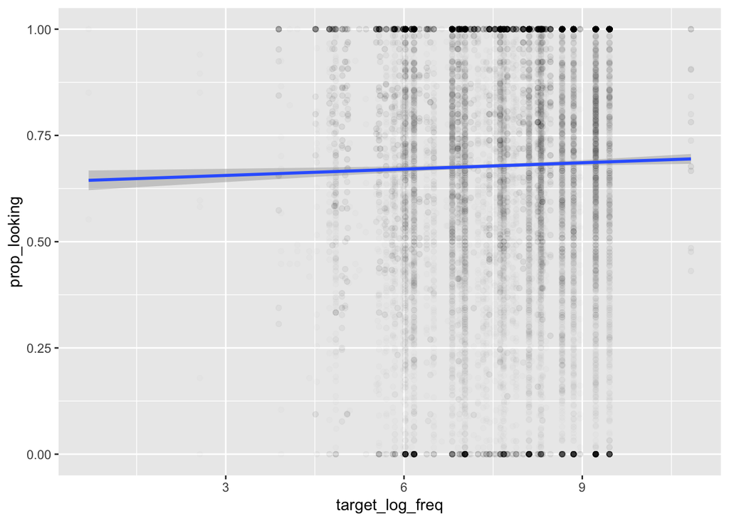

```r
#by age bin
acc_mod_freq %>%
  ggplot(aes(target_log_freq,prop_looking))+
  geom_point(alpha=0.01)+
  geom_smooth(method="lm")
```

#### By Age Bin

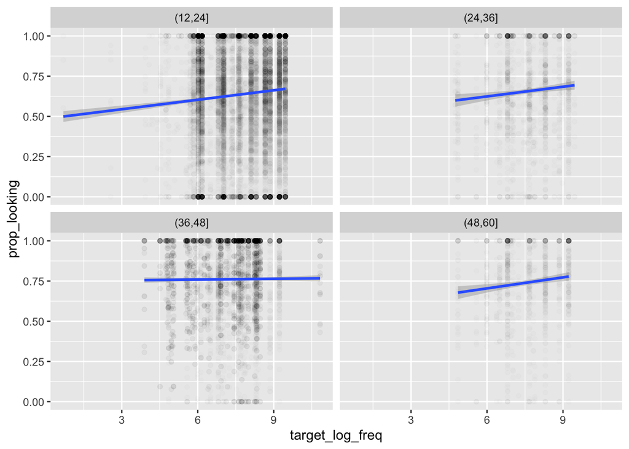

```r
#by age bin
acc_mod_freq %>%
  ggplot(aes(target_log_freq,prop_looking))+
  geom_point(alpha=0.01)+
  geom_smooth(method="lm")+
  facet_wrap(~age_binned)
```

#### By Dataset

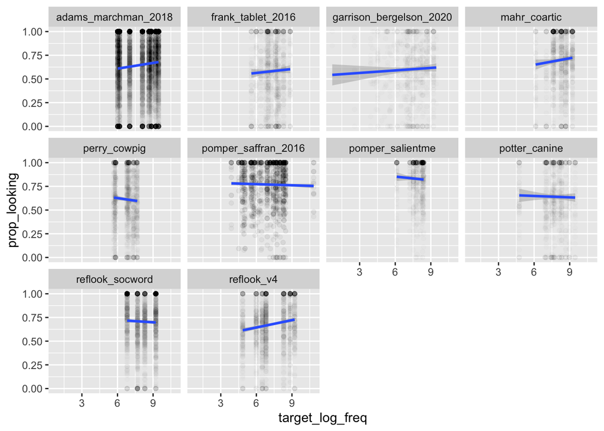

```r
#by dataset
acc_mod_freq %>%
  ggplot(aes(target_log_freq,prop_looking))+
  geom_point(alpha=0.01)+
  geom_smooth(method="lm")+
  facet_wrap(~dataset_name)
```

#### Plot summarized Items

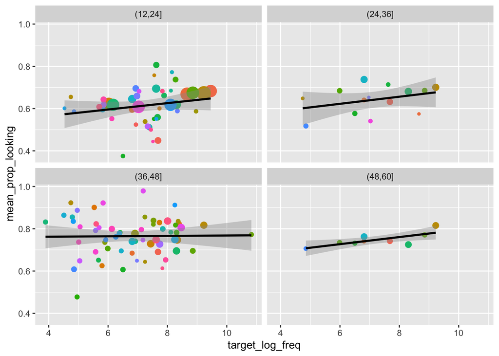

```r
n_cutoff <- 20
by_target_item_means %>%
  filter(N>n_cutoff) %>%
  ggplot(aes(target_log_freq,mean_prop_looking,size=N,color=target_label))+
  geom_point()+
  geom_smooth(method="lm",color="black")+
  theme(legend.position="none")+
  facet_wrap(~age_binned)
```

### Target Frequency

Predict proportion looking from target frequency, controlling for age. Frequency effect does not generalize across items

#### No item random effects

```r
m1 <- lmer(prop_looking ~ target_log_freq_centered+age_centered+(1|administration_id)+(1|dataset_name), data = acc_mod_freq)
summary(m1)
```

```
## Linear mixed model fit by REML. t-tests use Satterthwaite's method [
## lmerModLmerTest]
## Formula: prop_looking ~ target_log_freq_centered + age_centered + (1 |
##     administration_id) + (1 | dataset_name)
##    Data: acc_mod_freq
##
## REML criterion at convergence: 7615.1
##
## Scaled residuals:
##     Min      1Q  Median      3Q     Max
## -2.8705 -0.5962  0.1428  0.7675  2.3373
##
## Random effects:
##  Groups            Name        Variance Std.Dev.
##  administration_id (Intercept) 0.005157 0.07181
##  dataset_name      (Intercept) 0.003348 0.05787
##  Residual                      0.082544 0.28730
## Number of obs: 19809, groups:  administration_id, 1296; dataset_name, 10
##
## Fixed effects:
##                           Estimate Std. Error        df t value Pr(>|t|)
## (Intercept)              6.688e-01  1.875e-02 8.976e+00   35.66 5.57e-11 ***
## target_log_freq_centered 1.092e-02  1.733e-03 1.912e+04    6.30 3.04e-10 ***
## age_centered             4.968e-03  3.868e-04 2.049e+03   12.85  < 2e-16 ***
## ---
## Signif. codes:  0 '***' 0.001 '**' 0.01 '*' 0.05 '.' 0.1 ' ' 1
##
## Correlation of Fixed Effects:
##             (Intr) trg___
## trgt_lg_fr_  0.005
## age_centerd -0.030 -0.004
```

#### With item random effects

```r
m1A <- lmer(prop_looking ~ target_log_freq_centered+age_centered+(1|administration_id)+(1|dataset_name)+(1|target_label), data = acc_mod_freq)
summary(m1A)
```

```
## Linear mixed model fit by REML. t-tests use Satterthwaite's method [
## lmerModLmerTest]
## Formula: prop_looking ~ target_log_freq_centered + age_centered + (1 |
##     administration_id) + (1 | dataset_name) + (1 | target_label)
##    Data: acc_mod_freq
##
## REML criterion at convergence: 7229.7
##
## Scaled residuals:
##     Min      1Q  Median      3Q     Max
## -2.9770 -0.5863  0.1402  0.7535  2.3175
##
## Random effects:
##  Groups            Name        Variance Std.Dev.
##  administration_id (Intercept) 0.005275 0.07263
##  target_label      (Intercept) 0.005242 0.07240
##  dataset_name      (Intercept) 0.005284 0.07269
##  Residual                      0.080037 0.28291
## Number of obs: 19809, groups:
## administration_id, 1296; target_label, 131; dataset_name, 10
##
## Fixed effects:
##                            Estimate Std. Error         df t value Pr(>|t|)
## (Intercept)               6.597e-01  2.498e-02  1.117e+01  26.412 2.03e-11 ***
## target_log_freq_centered -7.480e-04  5.988e-03  1.179e+02  -0.125    0.901
## age_centered              5.014e-03  3.871e-04  2.604e+03  12.952  < 2e-16 ***
## ---
## Signif. codes:  0 '***' 0.001 '**' 0.01 '*' 0.05 '.' 0.1 ' ' 1
##
## Correlation of Fixed Effects:
##             (Intr) trg___
## trgt_lg_fr_  0.128
## age_centerd -0.023  0.000
```

#### Trial Count Threshold

```r
m1A_red <- lmer(prop_looking ~ target_log_freq_centered+age_centered+(1|administration_id)+(1|dataset_name)+(1|target_label), data = filter(acc_mod_freq,trial_count>20))
summary(m1A_red)
```

```
## Linear mixed model fit by REML. t-tests use Satterthwaite's method [
## lmerModLmerTest]
## Formula: prop_looking ~ target_log_freq_centered + age_centered + (1 |
##     administration_id) + (1 | dataset_name) + (1 | target_label)
##    Data: filter(acc_mod_freq, trial_count > 20)
##
## REML criterion at convergence: 7097.9
##
## Scaled residuals:
##     Min      1Q  Median      3Q     Max
## -2.9818 -0.5864  0.1417  0.7533  2.3219
##
## Random effects:
##  Groups            Name        Variance Std.Dev.
##  administration_id (Intercept) 0.005292 0.07275
##  target_label      (Intercept) 0.004974 0.07052
##  dataset_name      (Intercept) 0.005163 0.07186
##  Residual                      0.079865 0.28260
## Number of obs: 19583, groups:
## administration_id, 1296; target_label, 91; dataset_name, 10
##
## Fixed effects:
##                           Estimate Std. Error        df t value Pr(>|t|)
## (Intercept)              6.626e-01  2.485e-02 1.142e+01   26.66 1.21e-11 ***
## target_log_freq_centered 9.179e-04  6.573e-03 8.866e+01    0.14    0.889
## age_centered             5.010e-03  3.870e-04 2.566e+03   12.95  < 2e-16 ***
## ---
## Signif. codes:  0 '***' 0.001 '**' 0.01 '*' 0.05 '.' 0.1 ' ' 1
##
## Correlation of Fixed Effects:
##             (Intr) trg___
## trgt_lg_fr_  0.112
## age_centerd -0.024  0.002
```

### Target & Distractor Frequency

Add distractor frequency

#### No item random effects

```r
m2 <- lmer(prop_looking ~ target_log_freq_centered+distractor_log_freq_centered+age_centered+(1|administration_id)+(1|dataset_name), data = acc_mod_freq)
summary(m2)
```

```
## Linear mixed model fit by REML. t-tests use Satterthwaite's method [
## lmerModLmerTest]
## Formula:
## prop_looking ~ target_log_freq_centered + distractor_log_freq_centered +
##     age_centered + (1 | administration_id) + (1 | dataset_name)
##    Data: acc_mod_freq
##
## REML criterion at convergence: 7238.2
##
## Scaled residuals:
##     Min      1Q  Median      3Q     Max
## -2.8750 -0.5937  0.1394  0.7779  2.1728
##
## Random effects:
##  Groups            Name        Variance Std.Dev.
##  administration_id (Intercept) 0.005239 0.07238
##  dataset_name      (Intercept) 0.001948 0.04414
##  Residual                      0.082548 0.28731
## Number of obs: 18791, groups:  administration_id, 1294; dataset_name, 10
##
## Fixed effects:
##                               Estimate Std. Error        df t value Pr(>|t|)
## (Intercept)                  6.705e-01  1.467e-02 8.351e+00  45.713 2.55e-11
## target_log_freq_centered     1.039e-02  1.754e-03 1.797e+04   5.923 3.21e-09
## distractor_log_freq_centered 1.359e-03  1.644e-03 1.803e+04   0.826    0.409
## age_centered                 5.354e-03  3.956e-04 1.130e+03  13.533  < 2e-16
##
## (Intercept)                  ***
## target_log_freq_centered     ***
## distractor_log_freq_centered
## age_centered                 ***
## ---
## Signif. codes:  0 '***' 0.001 '**' 0.01 '*' 0.05 '.' 0.1 ' ' 1
##
## Correlation of Fixed Effects:
##             (Intr) trg___ dst___
## trgt_lg_fr_  0.008
## dstrctr_l__  0.008 -0.044
## age_centerd -0.037 -0.001 -0.001
```

#### Item random effects

```r
m2A <- lmer(prop_looking ~ target_log_freq_centered+distractor_log_freq_centered+age_centered+(1|administration_id)+(1|dataset_name)+(1|target_label)+(1|distractor_label), data = acc_mod_freq)
summary(m2A)
```

```
## Linear mixed model fit by REML. t-tests use Satterthwaite's method [
## lmerModLmerTest]
## Formula:
## prop_looking ~ target_log_freq_centered + distractor_log_freq_centered +
##     age_centered + (1 | administration_id) + (1 | dataset_name) +
##     (1 | target_label) + (1 | distractor_label)
##    Data: acc_mod_freq
##
## REML criterion at convergence: 6815.3
##
## Scaled residuals:
##     Min      1Q  Median      3Q     Max
## -2.9455 -0.5832  0.1331  0.7561  2.3376
##
## Random effects:
##  Groups            Name        Variance Std.Dev.
##  administration_id (Intercept) 0.005383 0.07337
##  distractor_label  (Intercept) 0.003738 0.06114
##  target_label      (Intercept) 0.004152 0.06443
##  dataset_name      (Intercept) 0.002502 0.05002
##  Residual                      0.079522 0.28200
## Number of obs: 18791, groups:
## administration_id, 1294; distractor_label, 131; target_label, 128; dataset_name, 10
##
## Fixed effects:
##                               Estimate Std. Error        df t value Pr(>|t|)
## (Intercept)                  6.623e-01  2.032e-02 1.430e+01  32.593 7.91e-15
## target_log_freq_centered     3.135e-03  6.586e-03 1.043e+02   0.476    0.635
## distractor_log_freq_centered 4.670e-03  5.651e-03 9.377e+01   0.826    0.411
## age_centered                 5.397e-03  3.963e-04 1.588e+03  13.618  < 2e-16
##
## (Intercept)                  ***
## target_log_freq_centered
## distractor_log_freq_centered
## age_centered                 ***
## ---
## Signif. codes:  0 '***' 0.001 '**' 0.01 '*' 0.05 '.' 0.1 ' ' 1
##
## Correlation of Fixed Effects:
##             (Intr) trg___ dst___
## trgt_lg_fr_  0.147
## dstrctr_l__  0.128 -0.049
## age_centerd -0.029  0.003  0.002
```

#### Trial Count Threshold

Restrict to items with >20 observations

```r
m2A_red <- lmer(prop_looking ~ target_log_freq_centered+distractor_log_freq_centered+age_centered+(1|administration_id)+(1|dataset_name)+(1|target_label)+(1|distractor_label), data = filter(acc_mod_freq,trial_count>20))
summary(m2A_red)
```

```
## Linear mixed model fit by REML. t-tests use Satterthwaite's method [
## lmerModLmerTest]
## Formula:
## prop_looking ~ target_log_freq_centered + distractor_log_freq_centered +
##     age_centered + (1 | administration_id) + (1 | dataset_name) +
##     (1 | target_label) + (1 | distractor_label)
##    Data: filter(acc_mod_freq, trial_count > 20)
##
## REML criterion at convergence: 6686.7
##
## Scaled residuals:
##     Min      1Q  Median      3Q     Max
## -2.9352 -0.5821  0.1348  0.7553  2.3422
##
## Random effects:
##  Groups            Name        Variance Std.Dev.
##  administration_id (Intercept) 0.005406 0.07352
##  distractor_label  (Intercept) 0.003814 0.06176
##  target_label      (Intercept) 0.003583 0.05986
##  dataset_name      (Intercept) 0.002407 0.04906
##  Residual                      0.079364 0.28172
## Number of obs: 18567, groups:
## administration_id, 1294; distractor_label, 121; target_label, 88; dataset_name, 10
##
## Fixed effects:
##                               Estimate Std. Error        df t value Pr(>|t|)
## (Intercept)                  6.660e-01  2.009e-02 1.489e+01  33.149 2.29e-15
## target_log_freq_centered     7.751e-03  7.410e-03 7.572e+01   1.046    0.299
## distractor_log_freq_centered 4.942e-03  5.790e-03 8.675e+01   0.854    0.396
## age_centered                 5.392e-03  3.960e-04 1.579e+03  13.616  < 2e-16
##
## (Intercept)                  ***
## target_log_freq_centered
## distractor_log_freq_centered
## age_centered                 ***
## ---
## Signif. codes:  0 '***' 0.001 '**' 0.01 '*' 0.05 '.' 0.1 ' ' 1
##
## Correlation of Fixed Effects:
##             (Intr) trg___ dst___
## trgt_lg_fr_  0.115
## dstrctr_l__  0.135 -0.080
## age_centerd -0.032  0.010  0.000
```

## Does AOA predict target looking?

### Target AOA

Predict proportion target looking from target aoa controlling for age.

#### No item random effects

```r
m3 <- lmer(prop_looking ~ target_aoa_centered+age_centered+(1|administration_id)+(1|dataset_name), data = acc_mod_freq_aoa)
summary(m3)
```

```
## Linear mixed model fit by REML. t-tests use Satterthwaite's method [
## lmerModLmerTest]
## Formula:
## prop_looking ~ target_aoa_centered + age_centered + (1 | administration_id) +
##     (1 | dataset_name)
##    Data: acc_mod_freq_aoa
##
## REML criterion at convergence: 6766.3
##
## Scaled residuals:
##     Min      1Q  Median      3Q     Max
## -2.9840 -0.5794  0.1241  0.7634  2.3476
##
## Random effects:
##  Groups            Name        Variance Std.Dev.
##  administration_id (Intercept) 0.006773 0.0823
##  dataset_name      (Intercept) 0.002275 0.0477
##  Residual                      0.079790 0.2825
## Number of obs: 18811, groups:  administration_id, 1291; dataset_name, 10
##
## Fixed effects:
##                       Estimate Std. Error         df t value Pr(>|t|)
## (Intercept)          6.748e-01  1.586e-02  8.526e+00  42.558 3.13e-11 ***
## target_aoa_centered -1.749e-03  8.107e-04  9.659e+03  -2.158    0.031 *
## age_centered         5.568e-03  3.938e-04  1.283e+03  14.140  < 2e-16 ***
## ---
## Signif. codes:  0 '***' 0.001 '**' 0.01 '*' 0.05 '.' 0.1 ' ' 1
##
## Correlation of Fixed Effects:
##             (Intr) trgt__
## trgt__cntrd -0.040
## age_centerd -0.035 -0.010
```

#### With item random effects

```r
m3A <- lmer(prop_looking ~ target_aoa_centered+age_centered+(1|administration_id)+(1|dataset_name)+(1|target_label), data = acc_mod_freq_aoa)
summary(m3A)
```

```
## Linear mixed model fit by REML. t-tests use Satterthwaite's method [
## lmerModLmerTest]
## Formula:
## prop_looking ~ target_aoa_centered + age_centered + (1 | administration_id) +
##     (1 | dataset_name) + (1 | target_label)
##    Data: acc_mod_freq_aoa
##
## REML criterion at convergence: 6342.1
##
## Scaled residuals:
##     Min      1Q  Median      3Q     Max
## -3.0564 -0.5753  0.1225  0.7469  2.3184
##
## Random effects:
##  Groups            Name        Variance Std.Dev.
##  administration_id (Intercept) 0.006970 0.08349
##  target_label      (Intercept) 0.006643 0.08150
##  dataset_name      (Intercept) 0.003183 0.05641
##  Residual                      0.077129 0.27772
## Number of obs: 18811, groups:
## administration_id, 1291; target_label, 100; dataset_name, 10
##
## Fixed effects:
##                       Estimate Std. Error         df t value Pr(>|t|)
## (Intercept)          6.715e-01  2.286e-02  1.595e+01  29.379 2.58e-15 ***
## target_aoa_centered -2.490e-03  3.214e-03  7.783e+01  -0.775    0.441
## age_centered         5.632e-03  3.956e-04  1.687e+03  14.236  < 2e-16 ***
## ---
## Signif. codes:  0 '***' 0.001 '**' 0.01 '*' 0.05 '.' 0.1 ' ' 1
##
## Correlation of Fixed Effects:
##             (Intr) trgt__
## trgt__cntrd -0.363
## age_centerd -0.019 -0.027
```

#### Trial Count Threshold

```r
m3A_red <- lmer(prop_looking ~ target_aoa_centered+age_centered+(1|administration_id)+(1|dataset_name)+(1|target_label), data = filter(acc_mod_freq_aoa,trial_count>20))
summary(m3A_red)
```

```
## Linear mixed model fit by REML. t-tests use Satterthwaite's method [
## lmerModLmerTest]
## Formula:
## prop_looking ~ target_aoa_centered + age_centered + (1 | administration_id) +
##     (1 | dataset_name) + (1 | target_label)
##    Data: filter(acc_mod_freq_aoa, trial_count > 20)
##
## REML criterion at convergence: 6262.1
##
## Scaled residuals:
##     Min      1Q  Median      3Q     Max
## -3.0592 -0.5730  0.1227  0.7451  2.3175
##
## Random effects:
##  Groups            Name        Variance Std.Dev.
##  administration_id (Intercept) 0.006989 0.08360
##  target_label      (Intercept) 0.005874 0.07664
##  dataset_name      (Intercept) 0.003095 0.05563
##  Residual                      0.077017 0.27752
## Number of obs: 18685, groups:
## administration_id, 1288; target_label, 79; dataset_name, 10
##
## Fixed effects:
##                       Estimate Std. Error         df t value Pr(>|t|)
## (Intercept)          6.745e-01  2.255e-02  1.607e+01   29.92 1.61e-15 ***
## target_aoa_centered -2.750e-03  3.162e-03  7.715e+01   -0.87    0.387
## age_centered         5.624e-03  3.954e-04  1.672e+03   14.22  < 2e-16 ***
## ---
## Signif. codes:  0 '***' 0.001 '**' 0.01 '*' 0.05 '.' 0.1 ' ' 1
##
## Correlation of Fixed Effects:
##             (Intr) trgt__
## trgt__cntrd -0.349
## age_centerd -0.022 -0.028
```

#### Alternate Analysis: AOA - Age

We considered an alternate analysis in which we considered *relative aoa* (age - age of acquisition). While this is a strong predictor, this is likely largely due to the strong relationship between age and proportion target looking.

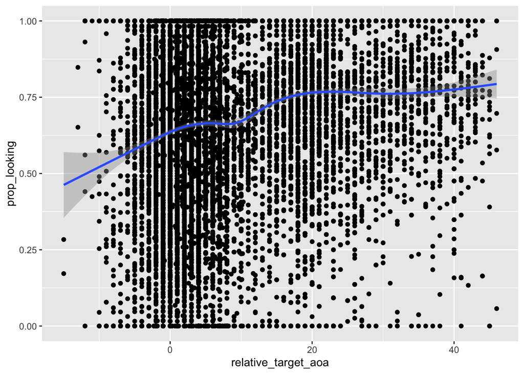

```r
#compute "relative" AOA
acc_mod_freq_aoa <- acc_mod_freq_aoa %>%
  mutate(relative_target_aoa=age-target_aoa,
         relative_distractor_aoa=age-distractor_aoa)

ggplot(acc_mod_freq_aoa,aes(relative_target_aoa,prop_looking))+
  geom_point()+
  geom_smooth()
```

```r
##target alone
m_diff_target <- lmer(prop_looking ~ relative_target_aoa+(1|administration_id)+(1|dataset_name)+(1|target_label)+(1|distractor_label), data = acc_mod_freq_aoa)
summary(m_diff_target)
```

```
## Linear mixed model fit by REML. t-tests use Satterthwaite's method [
## lmerModLmerTest]
## Formula: prop_looking ~ relative_target_aoa + (1 | administration_id) +
##     (1 | dataset_name) + (1 | target_label) + (1 | distractor_label)
##    Data: acc_mod_freq_aoa
##
## REML criterion at convergence: 6278.9
##
## Scaled residuals:
##     Min      1Q  Median      3Q     Max
## -3.0273 -0.5789  0.1179  0.7450  2.3507
##
## Random effects:
##  Groups            Name        Variance Std.Dev.
##  administration_id (Intercept) 0.006927 0.08323
##  target_label      (Intercept) 0.005379 0.07334
##  distractor_label  (Intercept) 0.003374 0.05809
##  dataset_name      (Intercept) 0.003045 0.05518
##  Residual                      0.076729 0.27700
## Number of obs: 18811, groups:
## administration_id, 1291; target_label, 100; distractor_label, 91; dataset_name, 10
##
## Fixed effects:
##                      Estimate Std. Error        df t value Pr(>|t|)
## (Intercept)         6.202e-01  2.258e-02 1.466e+01   27.46 5.09e-14 ***
## relative_target_aoa 5.615e-03  3.933e-04 1.848e+03   14.28  < 2e-16 ***
## ---
## Signif. codes:  0 '***' 0.001 '**' 0.01 '*' 0.05 '.' 0.1 ' ' 1
##
## Correlation of Fixed Effects:
##             (Intr)
## reltv_trgt_ -0.153
```

```r
##distractor alone
m_diff_distractor <- lmer(prop_looking ~ relative_distractor_aoa+(1|administration_id)+(1|dataset_name)+(1|target_label)+(1|distractor_label), data = acc_mod_freq_aoa)
summary(m_diff_distractor)
```

```
## Linear mixed model fit by REML. t-tests use Satterthwaite's method [
## lmerModLmerTest]
## Formula: prop_looking ~ relative_distractor_aoa + (1 | administration_id) +
##     (1 | dataset_name) + (1 | target_label) + (1 | distractor_label)
##    Data: acc_mod_freq_aoa
##
## REML criterion at convergence: 6285.9
##
## Scaled residuals:
##     Min      1Q  Median      3Q     Max
## -3.0265 -0.5795  0.1178  0.7455  2.3482
##
## Random effects:
##  Groups            Name        Variance Std.Dev.
##  administration_id (Intercept) 0.006923 0.08321
##  target_label      (Intercept) 0.005616 0.07494
##  distractor_label  (Intercept) 0.003482 0.05901
##  dataset_name      (Intercept) 0.003105 0.05572
##  Residual                      0.076745 0.27703
## Number of obs: 18811, groups:
## administration_id, 1291; target_label, 100; distractor_label, 91; dataset_name, 10
##
## Fixed effects:
##                          Estimate Std. Error        df t value Pr(>|t|)
## (Intercept)             6.208e-01  2.284e-02 1.452e+01   27.18 7.32e-14 ***
## relative_distractor_aoa 5.515e-03  3.932e-04 1.845e+03   14.03  < 2e-16 ***
## ---
## Signif. codes:  0 '***' 0.001 '**' 0.01 '*' 0.05 '.' 0.1 ' ' 1
##
## Correlation of Fixed Effects:
##             (Intr)
## rltv_dstrc_ -0.151
```

```r
## target and distractor
m_diff_td <- lmer(prop_looking ~ relative_target_aoa+relative_distractor_aoa+(1|administration_id)+(1|dataset_name)+(1|target_label)+(1|distractor_label), data = acc_mod_freq_aoa)
summary(m_diff_td)
```

```
## Linear mixed model fit by REML. t-tests use Satterthwaite's method [
## lmerModLmerTest]
## Formula: prop_looking ~ relative_target_aoa + relative_distractor_aoa +
##     (1 | administration_id) + (1 | dataset_name) + (1 | target_label) +
##     (1 | distractor_label)
##    Data: acc_mod_freq_aoa
##
## REML criterion at convergence: 6287.7
##
## Scaled residuals:
##     Min      1Q  Median      3Q     Max
## -3.0255 -0.5790  0.1177  0.7450  2.3529
##
## Random effects:
##  Groups            Name        Variance Std.Dev.
##  administration_id (Intercept) 0.006930 0.08325
##  target_label      (Intercept) 0.005552 0.07451
##  distractor_label  (Intercept) 0.003537 0.05947
##  dataset_name      (Intercept) 0.003012 0.05488
##  Residual                      0.076714 0.27697
## Number of obs: 18811, groups:
## administration_id, 1291; target_label, 100; distractor_label, 91; dataset_name, 10
##
## Fixed effects:
##                          Estimate Std. Error        df t value Pr(>|t|)
## (Intercept)              0.620420   0.022634 14.956755  27.411 3.36e-14 ***
## relative_target_aoa      0.008617   0.003056 92.403614   2.820  0.00588 **
## relative_distractor_aoa -0.003025   0.003054 92.167075  -0.991  0.32449
## ---
## Signif. codes:  0 '***' 0.001 '**' 0.01 '*' 0.05 '.' 0.1 ' ' 1
##
## Correlation of Fixed Effects:
##             (Intr) rltv_t_
## reltv_trgt_ -0.009
## rltv_dstrc_ -0.011 -0.992
```

### Target & Distractor AOA

#### No item random effects

```r
m4 <- lmer(prop_looking ~ target_aoa_centered+distractor_aoa_centered+age_centered+(1|administration_id)+(1|dataset_name), data = acc_mod_freq_aoa)
summary(m4)
```

```
## Linear mixed model fit by REML. t-tests use Satterthwaite's method [
## lmerModLmerTest]
## Formula: prop_looking ~ target_aoa_centered + distractor_aoa_centered +
##     age_centered + (1 | administration_id) + (1 | dataset_name)
##    Data: acc_mod_freq_aoa
##
## REML criterion at convergence: 6774.4
##
## Scaled residuals:
##     Min      1Q  Median      3Q     Max
## -2.9697 -0.5811  0.1264  0.7644  2.3498
##
## Random effects:
##  Groups            Name        Variance Std.Dev.
##  administration_id (Intercept) 0.006767 0.08226
##  dataset_name      (Intercept) 0.002288 0.04783
##  Residual                      0.079778 0.28245
## Number of obs: 18811, groups:  administration_id, 1291; dataset_name, 10
##
## Fixed effects:
##                           Estimate Std. Error         df t value Pr(>|t|)
## (Intercept)              6.750e-01  1.590e-02  8.534e+00  42.459 3.13e-11 ***
## target_aoa_centered     -8.108e-04  9.351e-04  1.620e+04  -0.867    0.386
## distractor_aoa_centered -1.813e-03  9.002e-04  1.716e+04  -2.014    0.044 *
## age_centered             5.570e-03  3.938e-04  1.292e+03  14.145  < 2e-16 ***
## ---
## Signif. codes:  0 '***' 0.001 '**' 0.01 '*' 0.05 '.' 0.1 ' ' 1
##
## Correlation of Fixed Effects:
##             (Intr) trgt__ dstr__
## trgt__cntrd -0.032
## dstrctr__cn -0.006 -0.498
## age_centerd -0.035 -0.008 -0.002
```

#### Item random effects

```r
m4A <- lmer(prop_looking ~ target_aoa_centered+distractor_aoa_centered+age_centered+(1|administration_id)+(1|dataset_name)+(1|target_label)+(1|distractor_label), data = acc_mod_freq_aoa)
summary(m4A)
```

```
## Linear mixed model fit by REML. t-tests use Satterthwaite's method [
## lmerModLmerTest]
## Formula: prop_looking ~ target_aoa_centered + distractor_aoa_centered +
##     age_centered + (1 | administration_id) + (1 | dataset_name) +
##     (1 | target_label) + (1 | distractor_label)
##    Data: acc_mod_freq_aoa
##
## REML criterion at convergence: 6296.2
##
## Scaled residuals:
##     Min      1Q  Median      3Q     Max
## -3.0257 -0.5793  0.1177  0.7455  2.3478
##
## Random effects:
##  Groups            Name        Variance Std.Dev.
##  administration_id (Intercept) 0.006933 0.08326
##  target_label      (Intercept) 0.005633 0.07505
##  distractor_label  (Intercept) 0.003544 0.05953
##  dataset_name      (Intercept) 0.002817 0.05308
##  Residual                      0.076714 0.27697
## Number of obs: 18811, groups:
## administration_id, 1291; target_label, 100; distractor_label, 91; dataset_name, 10
##
## Fixed effects:
##                           Estimate Std. Error         df t value Pr(>|t|)
## (Intercept)              6.664e-01  2.402e-02  1.990e+01  27.739   <2e-16 ***
## target_aoa_centered     -6.959e-03  3.743e-03  6.968e+01  -1.859   0.0672 .
## distractor_aoa_centered  4.600e-03  3.642e-03  6.647e+01   1.263   0.2110
## age_centered             5.607e-03  3.943e-04  1.634e+03  14.222   <2e-16 ***
## ---
## Signif. codes:  0 '***' 0.001 '**' 0.01 '*' 0.05 '.' 0.1 ' ' 1
##
## Correlation of Fixed Effects:
##             (Intr) trgt__ dstr__
## trgt__cntrd -0.259
## dstrctr__cn -0.192 -0.373
## age_centerd -0.015 -0.024 -0.017
```

#### Trial Count Threshold

```r
m4A_red <- lmer(prop_looking ~ target_aoa_centered+distractor_aoa_centered+age_centered+(1|administration_id)+(1|dataset_name)+(1|target_label)+(1|distractor_label), data = filter(acc_mod_freq_aoa,trial_count>20))
summary(m4A_red)
```

```
## Linear mixed model fit by REML. t-tests use Satterthwaite's method [
## lmerModLmerTest]
## Formula: prop_looking ~ target_aoa_centered + distractor_aoa_centered +
##     age_centered + (1 | administration_id) + (1 | dataset_name) +
##     (1 | target_label) + (1 | distractor_label)
##    Data: filter(acc_mod_freq_aoa, trial_count > 20)
##
## REML criterion at convergence: 6216.8
##
## Scaled residuals:
##     Min      1Q  Median      3Q     Max
## -3.0264 -0.5785  0.1179  0.7453  2.3494
##
## Random effects:
##  Groups            Name        Variance Std.Dev.
##  administration_id (Intercept) 0.006966 0.08346
##  distractor_label  (Intercept) 0.003534 0.05944
##  target_label      (Intercept) 0.004429 0.06655
##  dataset_name      (Intercept) 0.002646 0.05143
##  Residual                      0.076615 0.27679
## Number of obs: 18685, groups:
## administration_id, 1288; distractor_label, 87; target_label, 79; dataset_name, 10
##
## Fixed effects:
##                           Estimate Std. Error         df t value Pr(>|t|)
## (Intercept)              6.674e-01  2.321e-02  1.997e+01  28.750   <2e-16 ***
## target_aoa_centered     -7.589e-03  3.718e-03  7.286e+01  -2.041   0.0449 *
## distractor_aoa_centered  5.117e-03  3.681e-03  6.649e+01   1.390   0.1691
## age_centered             5.604e-03  3.940e-04  1.592e+03  14.223   <2e-16 ***
## ---
## Signif. codes:  0 '***' 0.001 '**' 0.01 '*' 0.05 '.' 0.1 ' ' 1
##
## Correlation of Fixed Effects:
##             (Intr) trgt__ dstr__
## trgt__cntrd -0.205
## dstrctr__cn -0.215 -0.417
## age_centerd -0.019 -0.028 -0.014
```

### Target & Distractor AOA

Using Mike Frank’s suggestion for a Luce choice predictor (1/target_aoa)/(1/target_aoa+1/distractor_aoa)

#### No item random effects

```r
m4B <- lmer(prop_looking ~ luce+age_centered+(1|administration_id)+(1|dataset_name), data = acc_mod_freq_aoa)
summary(m4B)
```

```
## Linear mixed model fit by REML. t-tests use Satterthwaite's method [
## lmerModLmerTest]
## Formula: prop_looking ~ luce + age_centered + (1 | administration_id) +
##     (1 | dataset_name)
##    Data: acc_mod_freq_aoa
##
## REML criterion at convergence: 6762
##
## Scaled residuals:
##     Min      1Q  Median      3Q     Max
## -2.9779 -0.5769  0.1258  0.7631  2.3433
##
## Random effects:
##  Groups            Name        Variance Std.Dev.
##  administration_id (Intercept) 0.006783 0.08236
##  dataset_name      (Intercept) 0.002373 0.04871
##  Residual                      0.079802 0.28249
## Number of obs: 18811, groups:  administration_id, 1291; dataset_name, 10
##
## Fixed effects:
##                Estimate Std. Error         df t value Pr(>|t|)
## (Intercept)   6.942e-01  3.050e-02  1.079e+02   22.76   <2e-16 ***
## luce         -4.148e-02  5.185e-02  1.813e+04   -0.80    0.424
## age_centered  5.561e-03  3.943e-04  1.327e+03   14.10   <2e-16 ***
## ---
## Signif. codes:  0 '***' 0.001 '**' 0.01 '*' 0.05 '.' 0.1 ' ' 1
##
## Correlation of Fixed Effects:
##             (Intr) luce
## luce        -0.848
## age_centerd -0.022  0.004
```

#### With item random effects

```r
m4C <- lmer(prop_looking ~ luce+age_centered+(1|administration_id)+(1|dataset_name)+(1|target_label)+(1|distractor_label), data = acc_mod_freq_aoa)
summary(m4C)
```

```
## Linear mixed model fit by REML. t-tests use Satterthwaite's method [
## lmerModLmerTest]
## Formula: prop_looking ~ luce + age_centered + (1 | administration_id) +
##     (1 | dataset_name) + (1 | target_label) + (1 | distractor_label)
##    Data: acc_mod_freq_aoa
##
## REML criterion at convergence: 6279.1
##
## Scaled residuals:
##     Min      1Q  Median      3Q     Max
## -3.0254 -0.5784  0.1181  0.7454  2.3430
##
## Random effects:
##  Groups            Name        Variance Std.Dev.
##  administration_id (Intercept) 0.006934 0.08327
##  target_label      (Intercept) 0.005631 0.07504
##  distractor_label  (Intercept) 0.003526 0.05938
##  dataset_name      (Intercept) 0.002596 0.05096
##  Residual                      0.076715 0.27698
## Number of obs: 18811, groups:
## administration_id, 1291; target_label, 100; distractor_label, 91; dataset_name, 10
##
## Fixed effects:
##               Estimate Std. Error        df t value Pr(>|t|)
## (Intercept)  4.542e-01  1.181e-01 8.533e+01   3.846 0.000231 ***
## luce         4.108e-01  2.324e-01 8.470e+01   1.768 0.080688 .
## age_centered 5.595e-03  3.934e-04 1.498e+03  14.223  < 2e-16 ***
## ---
## Signif. codes:  0 '***' 0.001 '**' 0.01 '*' 0.05 '.' 0.1 ' ' 1
##
## Correlation of Fixed Effects:
##             (Intr) luce
## luce        -0.983
## age_centerd -0.010  0.004
```

## Combined Effect of Frequency and AOA

Next, we combined all frequency and AOA predictors into a single model.

### no item random effects

```r
m5 <- lmer(prop_looking ~ target_log_freq_centered+distractor_log_freq_centered+target_aoa_centered+distractor_aoa_centered+age_centered+(1|administration_id)+(1|dataset_name), data = acc_mod_freq_aoa)
summary(m5)
```

```
## Linear mixed model fit by REML. t-tests use Satterthwaite's method [
## lmerModLmerTest]
## Formula:
## prop_looking ~ target_log_freq_centered + distractor_log_freq_centered +
##     target_aoa_centered + distractor_aoa_centered + age_centered +
##     (1 | administration_id) + (1 | dataset_name)
##    Data: acc_mod_freq_aoa
##
## REML criterion at convergence: 6729.2
##
## Scaled residuals:
##     Min      1Q  Median      3Q     Max
## -2.9164 -0.5824  0.1306  0.7592  2.2934
##
## Random effects:
##  Groups            Name        Variance Std.Dev.
##  administration_id (Intercept) 0.006802 0.08247
##  dataset_name      (Intercept) 0.002353 0.04851
##  Residual                      0.079485 0.28193
## Number of obs: 18811, groups:  administration_id, 1291; dataset_name, 10
##
## Fixed effects:
##                                Estimate Std. Error         df t value Pr(>|t|)
## (Intercept)                   6.748e-01  1.612e-02  8.599e+00  41.873 3.05e-11
## target_log_freq_centered      1.400e-02  2.031e-03  1.782e+04   6.894 5.59e-12
## distractor_log_freq_centered -1.217e-02  2.467e-03  1.812e+04  -4.932 8.23e-07
## target_aoa_centered           2.387e-03  1.021e-03  1.526e+04   2.337 0.019436
## distractor_aoa_centered      -3.454e-03  1.039e-03  1.733e+04  -3.324 0.000891
## age_centered                  5.550e-03  3.940e-04  1.332e+03  14.087  < 2e-16
##
## (Intercept)                  ***
## target_log_freq_centered     ***
## distractor_log_freq_centered ***
## target_aoa_centered          *
## distractor_aoa_centered      ***
## age_centered                 ***
## ---
## Signif. codes:  0 '***' 0.001 '**' 0.01 '*' 0.05 '.' 0.1 ' ' 1
##
## Correlation of Fixed Effects:
##             (Intr) trg___ dst___ trgt__ dstr__
## trgt_lg_fr_ -0.022
## dstrctr_l__ -0.030 -0.094
## trgt__cntrd -0.035  0.394 -0.133
## dstrctr__cn -0.023  0.080  0.486 -0.410
## age_centerd -0.034 -0.011 -0.005 -0.011 -0.005
```

### item random effects

Target AOA is the only effect that remains significant after accounting for non-independence between items (targets and distractors).

```r
m5A <- lmer(prop_looking ~ target_log_freq_centered+distractor_log_freq_centered+target_aoa_centered+distractor_aoa_centered+age_centered+(1|administration_id)+(1|dataset_name)+(1|target_label)+(1|distractor_label), data = acc_mod_freq_aoa)
summary(m5A)
```

```
## Linear mixed model fit by REML. t-tests use Satterthwaite's method [
## lmerModLmerTest]
## Formula:
## prop_looking ~ target_log_freq_centered + distractor_log_freq_centered +
##     target_aoa_centered + distractor_aoa_centered + age_centered +
##     (1 | administration_id) + (1 | dataset_name) + (1 | target_label) +
##     (1 | distractor_label)
##    Data: acc_mod_freq_aoa
##
## REML criterion at convergence: 6310.2
##
## Scaled residuals:
##     Min      1Q  Median      3Q     Max
## -3.0263 -0.5782  0.1193  0.7462  2.3468
##
## Random effects:
##  Groups            Name        Variance Std.Dev.
##  administration_id (Intercept) 0.006931 0.08325
##  target_label      (Intercept) 0.005924 0.07697
##  distractor_label  (Intercept) 0.003640 0.06033
##  dataset_name      (Intercept) 0.002836 0.05325
##  Residual                      0.076705 0.27696
## Number of obs: 18811, groups:
## administration_id, 1291; target_label, 100; distractor_label, 91; dataset_name, 10
##
## Fixed effects:
##                                Estimate Std. Error         df t value Pr(>|t|)
## (Intercept)                   6.660e-01  2.448e-02  2.066e+01  27.210   <2e-16
## target_log_freq_centered     -7.509e-03  9.345e-03  7.476e+01  -0.804   0.4242
## distractor_log_freq_centered  1.376e-03  1.155e-02  5.874e+01   0.119   0.9056
## target_aoa_centered          -8.406e-03  4.169e-03  7.033e+01  -2.016   0.0476
## distractor_aoa_centered       5.110e-03  4.478e-03  5.780e+01   1.141   0.2585
## age_centered                  5.610e-03  3.943e-04  1.646e+03  14.227   <2e-16
##
## (Intercept)                  ***
## target_log_freq_centered
## distractor_log_freq_centered
## target_aoa_centered          *
## distractor_aoa_centered
## age_centered                 ***
## ---
## Signif. codes:  0 '***' 0.001 '**' 0.01 '*' 0.05 '.' 0.1 ' ' 1
##
## Correlation of Fixed Effects:
##             (Intr) trg___ dst___ trgt__ dstr__
## trgt_lg_fr_  0.012
## dstrctr_l__ -0.127 -0.148
## trgt__cntrd -0.233  0.408 -0.077
## dstrctr__cn -0.229 -0.114  0.567 -0.335
## age_centerd -0.014 -0.009 -0.007 -0.026 -0.017
```

```r
#vif.mer(m5A)
```